# Statistik och dataanalys I, 15 hp

Inlämningsuppgift 1

Authors

Namn Daniel Lännerholm Palm

Namn Alice Lönnerblad

Namn Anton Bylin

Publicerad

February 17, 2023

**Varning**

Den här inlämningsuppgiften förutsätter att följande paket finns installerade:

- `mosaic`
- `dplyr`
- `geosphere`
- `leaflet`

Paket kan installeras via kommandot `install.packages('packagename')`, där `'packagename'` är namnet på paketet, t.ex `'mosaic'`.

## Introduktion

I den första inlämningsuppgiften ska ni självständigt i grupper om tre analysera ett dataset i programmeringsspråket R. Till skillnad från datorlaborationerna finns det minimalt med kodexempel. Datorlaborationerna går igenom de flesta momenten som behandlas i inlämningsuppgiften, så se till att göra klart dessa innan.

**Instruktioner**

I denna inlämningsuppgift ska ni analysera ett datamaterial som innehåller en mängd olika variabler från en totalundersökning[^1] i Boston 1970 som aggregerats till ca 500 censusdistrikt. Datasetet förekommer i många olika varianter. Här använder vi en modifierad version[^2] av originaldata[^3] som använts i en studie[^4] där författarna predikterar medianhuspriset i ett censusdistrikt givet en uppsättning förklarande variabler.

Följande variabler finns i datasetet `boston_census_data.Rdata` ([ladda ner](https://github.com/StatisticsSU/SDA1/blob/main/assignments/assignment1/Boston_census_data.RData?raw=true)) för 480 observationer. Notera att en observation motsvarar ett censusdistrikt:

- `town`: Stadsdel.
- `longitude`: Longitud koordinat.
- `latitude`: Latitud koordinat.
- `median_home_value`: Medianhuspriset (enhet 1K USD).
- `crime_rate`: Brott (per 1000 invånare).
- `zoned_25k_p`: Andel av stadsdelens bostadsmark ämnad för marklotter större än 25000 kvadratfot.
- `indust_p`: Andel tunnland ägd av företag utanför detaljhandel.
- `borders_charles`: Charles River dummy variabel (= 1 om området gränsar till floden, 0 annars).
- `NOx`: Koncentration av kväveoxider (andelar per 10 miljon).
- `n_rooms_avg`: Genomsnitt antal rum i ägda bostäder.
- `before_1940_p`: Andel ägda bostäder byggda före 1940.
- `employ_dist`: Viktat avstånd till fem arbetsförmedlingscentra i Boston.
- `radial_access`: Index som mäter tillgång till stadsmotorvägar.
- `tax_rate`: Fastighetsskatt per 10000 USD.
- `pupil_teacher_ratio`: Lärartäthet mätt som elev per lärare.
- `lower_stat_pct`: Procentandel underklass definerad som en av två: (i) andel vuxna utan gymnasieutbildning eller (ii) andel män som genomför okvalificerat arbete.

Bland de förklarande variablerna som använts i studien (ej med i datasetet) finns en icke-linjär interaktion av latitud och longitud koordinaterna för att modellera medianhuspriset spatiellt (dvs deras modell använder censusdistriktens geografiska platser för att fånga den spatiella variationen i huspriser, dvs geografisk variation). Det här sättet att modellera spatiellt beroende är överkurs[^5], så ni kommer att få göra följande förenkling för att fånga det geografiska beroendet i medianhuspriset. Genom att använda latitud och longitud koordinaterna kan ni beräkna avståndet till en central plats i Boston. Ni kan sedan inkludera detta avstånd som en förklarande variabel i en regressionsmodell, för att se om den förklarar variation i medianhuspriserna.

I sista uppgiften ska ni föreslå en prognosmodell för medianhuspriset där ni får välja vilka förklaringsvariabler ni vill ha med (ni vår välja bland en delmängd av de som listas ovanför, se Uppgift 5.4). Ni ska sedan använda er modell för att prognostisera medianhuspriset för tio censusdistrikt i datasetet `boston_districts_to_predict.Rdata` ([ladda ner](https://github.com/StatisticsSU/SDA1/blob/main/assignments/assignment1/Boston_districts_to_predict.RData?raw=true)). Det här datasetet har endast de förklarande variablerna, dvs alla de variabler ni får använda förutom medianhuspriset. När vi rättar era inlämningsuppgifter kommer vi att jämföra prognoserna mot de faktiska värden (vi har tillgång till dessa). De tre bästa prognosmakarna kommer att publiceras på hemsidan.

Inlämningsuppgiften ska lämnas in i form av ett html dokument genererat av Quarto. **Kontrollera noga att du inte har några felmeddelande och att dokumentet kompileras utan problem**. Använd tydliga figurer och namnge axlarna med tydliga variabelnamn. Glöm inte att skriva era namn ovanför istället för Namn 1, Namn 2 och Namn 3.

## 0. Ladda in data

#### 💪 Uppgift 0.1

Ställ in arbetsmappen samt ladda in dataseten `Boston_census_data.Rdata` och `Boston_districts_to_predict.Rdata` (länkar för att ladda ner data finns i Instruktioner avsnittet ovan).

**Uppgift 0.1 - Svar**

```r
##install and require packages
required_pkgs <- c("mosaic", "dplyr", "geosphere", "leaflet", "corrplot")
pkg_is_installed <- required_pkgs %in% rownames(installed.packages())
if(any(pkg_is_installed = FALSE)) {

  install.packages(required_pkgs[!pkg_is_installed])
}
invisible(lapply(required_pkgs, FUN = function(pkgs) {
  do.call("require", list(pkgs))
}))
```

```
The 'mosaic' package masks several functions from core packages in order to add
additional features.  The original behavior of these functions should not be affected by this.
```

```r
#load boston census data
load(file = url("https://github.com/StatisticsSU/SDA1/blob/main/assignments/assignment1/Boston_census_data.RData?raw=true"))
load(file = url("https://github.com/StatisticsSU/SDA1/blob/main/assignments/assignment1/Boston_districts_to_predict.RData?raw=true"))
```

## 1. Kriminalitet i Boston

I detta avsnitt ska ni analysera kriminaliteten i Boston med hjälp av variabeln `crime_rate`.

#### 💪 Uppgift 1.1

Vad kan man generellt säga om kriminaliteten i censusdistrikten? Använd lämpliga figurer samt fördelningsmått som underlag.

**Uppgift 1.1 - Svar**

Vi utgår ifrån att outliers inte är felskrivningar, och att de värdena är korrekta. Dessutom, tror vi, är det dessa punker som är mest intressanta när man vill vet mer om brottsligheten i Boston.

Figurerna och fördelningsmåtten ger oss en bild av ett mestadels fridfullt Boston, där kriminaliteten är koncentrerad till ett relativt fåtal områden, s.k. hot-spots. Varför brottsligheten är koncentrerad i just de områdena vet vi inte än.

```r
favstats(Boston_census_data$crime_rate)
```

```
     min        Q1   median       Q3     max    mean       sd   n missing
 0.00632 0.0829725 0.253715 3.681942 88.9762 3.66526 8.746156 480       0
```

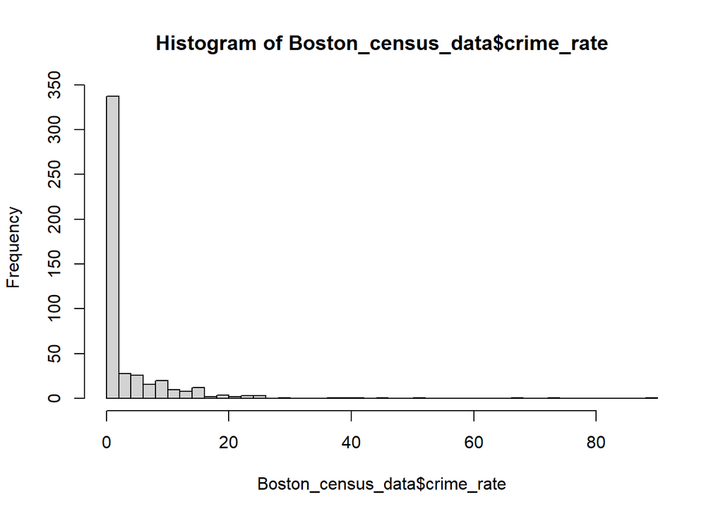

```r
hist(Boston_census_data$crime_rate, breaks = 50)
```

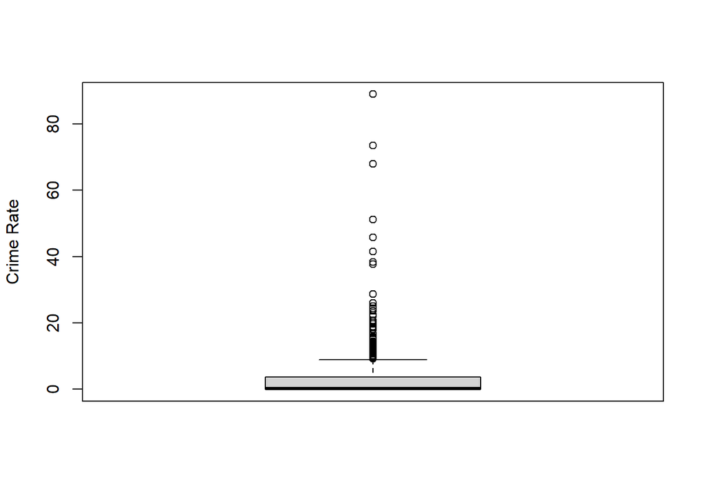

```r
boxplot(Boston_census_data$crime_rate, ylab = "Crime Rate")
```

#### 💪 Uppgift 1.2

Varierar brottsligheten i Boston beroende på den kategoriska variabeln `town`? Det finns 88 olika utfall av `town` (dvs 88 olika stadsdelar). Välj ut `Boston East Boston`, `Boston Downtown`,`Cambridge`, samt två valfria stadsdelar för att besvara frågan. Frågan besvaras med hjälp av lämpligt valda figurer och statistiska mått.

**Tips**

Skapa en ny data frame som filtrerar `Boston_census_data` (till exempel genom `filter()` funktionen) utefter de stadsdelarna ni är intresserade utav innan ni påbörjar analysen.

**Uppgift 1.2 - Svar**

Boxplotten visar ett klart samband mellan town och crime_rate.

Downton Boston har högst medianvärde, och kvartilerna ligger högre än motsvarande kvartiler alla andra towns.

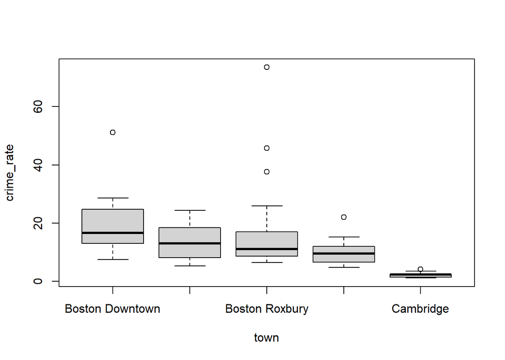

```r
selected_towns <- c("Boston East Boston", "Boston Downtown", "Cambridge", "Boston Roxbury", "Boston Savin Hill")
town_subset <- Boston_census_data %>%
  filter(town %in% selected_towns)
boxplot(crime_rate ~ town, data = town_subset)
```

#### 💪 Uppgift 1.3

Vilka tre variabler i datasetet `Boston_census_data` korrelerar mest med brottslighet? Beskriv det parvisa sambandet mellan brottslighet och vardera av dessa tre variabler.

**Tips**

Kom ihåg att korrelation är ett beroendemått för *numeriska variabler*.

**Uppgift 1.3 - Svar**

Eftersom korrelation bara är giltig för numeriska variabler tog vi först bort de som R ansåg vara kategoriska med hjälp av funktionen ‘select_if(is.numeric)’.

Sedan tog vi även bort variabeln ‘border_charles’, som är en dummy-variabel, och alltså inte är numerisk.

Tabellen visat att de tre variabler som har högst korrelation med crime_rate är

- radial_access (0.62)
- tax_rate (0.58)
- lower_stat_pct (0.46)

Om vi plottar variablerna mot varandra (crime rate är i log-skala för att tydligare representera data) ser vi ett linjärt samband mellan variablerna.

```r
strictly_numerical <- Boston_census_data %>%
  select_if(is.numeric) %>%
  select(-any_of(c("borders_charles")))

correlations <- cor(strictly_numerical)
sorted_crime_rate_correlations <- sort(correlations[,4])
sorted_crime_rate_correlations
```

```
  median_home_value         employ_dist         n_rooms_avg         zoned_25k_p
        -0.44962375         -0.37796919         -0.21296259         -0.19606744
           latitude           longitude pupil_teacher_ratio       before_1940_p
        -0.09175993          0.05586009          0.28335363          0.34989810
           indust_p                 NOx      lower_stat_pct            tax_rate
         0.40318245          0.41548451          0.46372510          0.58024439
      radial_access          crime_rate
         0.62346198          1.00000000
```

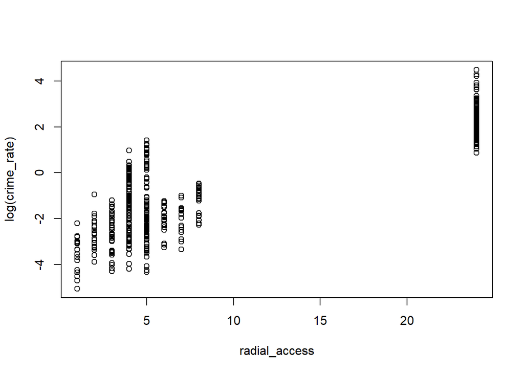

```r
plot(log(crime_rate) ~ radial_access, data = Boston_census_data)
```

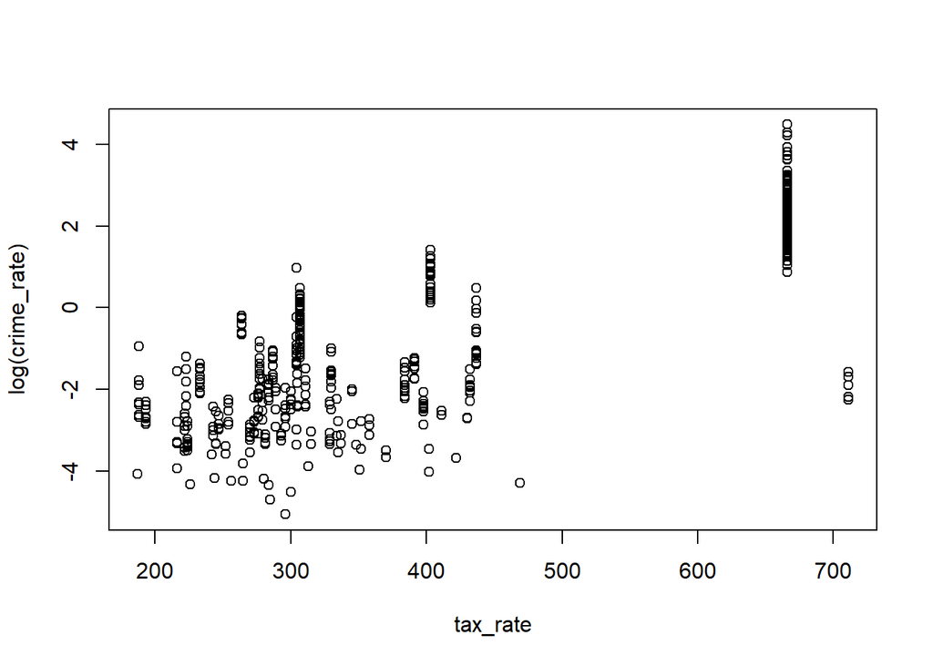

```r
plot(log(crime_rate) ~ tax_rate, data = Boston_census_data)
```

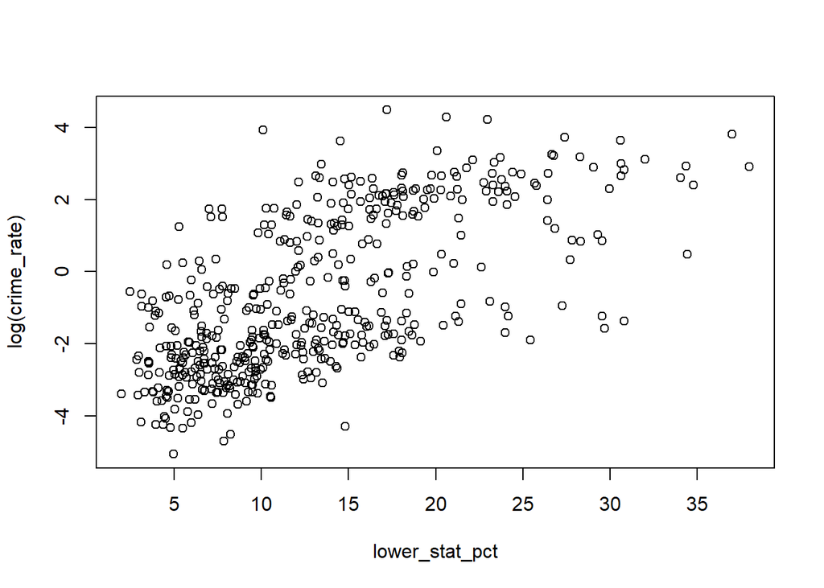

```r
plot(log(crime_rate) ~ lower_stat_pct, data = Boston_census_data)
```

## 2. Fastighetsskatt i Boston

I detta avsnitt ska ni analysera fastighetsskatten i Boston med hjälp av variabeln `tax_rate`.

#### 💪 Uppgift 2.1

Vad kan man generellt säga om fastighetsskatten i censusdistrikten? Använd lämpliga figurer samt fördelningsmått som underlag.

**Uppgift 2.1 - Svar**

Histogrammet visar hur stor andel av distrikten som betalar en viss fastighetsskatt.

Distributionen av fastighetsskatten verkar vara bimodal (kanske till och med multimodal), med en topp strax över 300 per 10000 USD och en annan topp på 660 per 10000 USD. Mellan topparna är det en stor glipa.

Multimodaltiteten gör att det blir svårt att uttala sig om distributionen. Det är t.ex lite oklart vilken form distributionen har, och vi kan inte säga om den t.ex är normalformad eller skev. Dessutom hamnar medianen (330) och medelvärdet (409) mitt i en dal, och alltså skulle distributionen ha ett lägesmått som ingen av värden ligger i närheten av. Multimodaliteten ger oss också problem när vi vill se på spridningen - t.ex så ligger IQR till hälften i ett område utan några värden alls.

Här skulle det nog varea klokt att dela upp i kategorier, och på så sätt bli av med multimodaliteten. Det skulle förmodligen vara enklare och bättre att analysera distributionerna av de enskilda kategorierna.

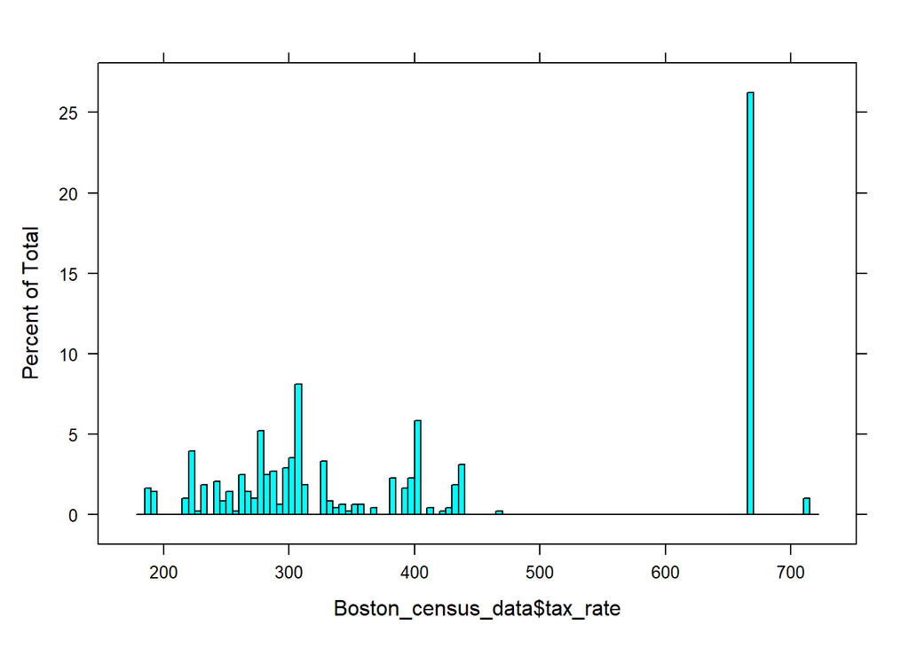

```r
histogram(Boston_census_data$tax_rate, breaks = 100)
```

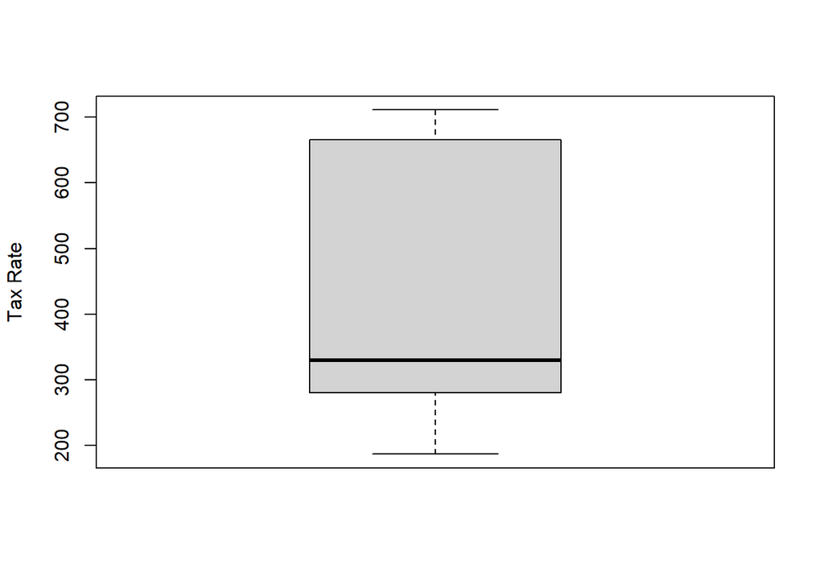

```r
boxplot(Boston_census_data$tax_rate, ylab = "Tax Rate")
```

```r
favstats(Boston_census_data$tax_rate)
```

```
 min     Q1 median  Q3 max     mean       sd   n missing
 187 280.75    330 666 711 409.3271 168.5777 480       0
```

#### 💪 Uppgift 2.2

Låt oss skapa en ny variabel `cat_tax` som anger om ett censusdistrikt betalar låg (`low`), medel (`medium`), eller hög (`high`) fastighetsskatt. Vi definerar skattekategorierna enligt

- `low`: `tax_rate` $\leq$ 250,
- `medium`: 250 $<$ `tax_rate` $\leq$ 400,
- `high`: `tax_rate` $>$ 400.

Följande kod skapar och lägger till variabeln `cat_tax` i `Boston_census_data`

```r
Boston_census_data$cat_tax <- cut(Boston_census_data$tax_rate,
              breaks=c(0, 250, 400, 800),
              labels=c('Low', 'Medium', 'High'))
```

Finns det ett samband mellan vilken skattekategori ett censusdistrikt tillhör och dess angränsning till Charles River? Förklara med hjälp av lämplig tabell samt figur.

**Uppgift 2.2 - Svar**

Vi undrar vad andelen av varje skattekategori är givet borders_charles. Tabellen och figuren visar endast ett svagt samband mellan vilken skattekategori ett distrikt har, och dess angränsning till Charles River. De distrikt som ligger i anslutning till Charles är oftare i skattekategorin “medium” än de distrikt som inte ligger nära Charles. Därmed följer att fördelningen av distrikt som inte ligger nära Charles har en högre andel observationer i “high” och “low” skattekategorin.

```r
t <- tally(~ cat_tax | borders_charles, data = Boston_census_data, format = "percent")
t
```

```
        borders_charles
cat_tax         0        1
  Low    13.30377 10.34483
  Medium 47.00665 55.17241
  High   39.68958 34.48276
```

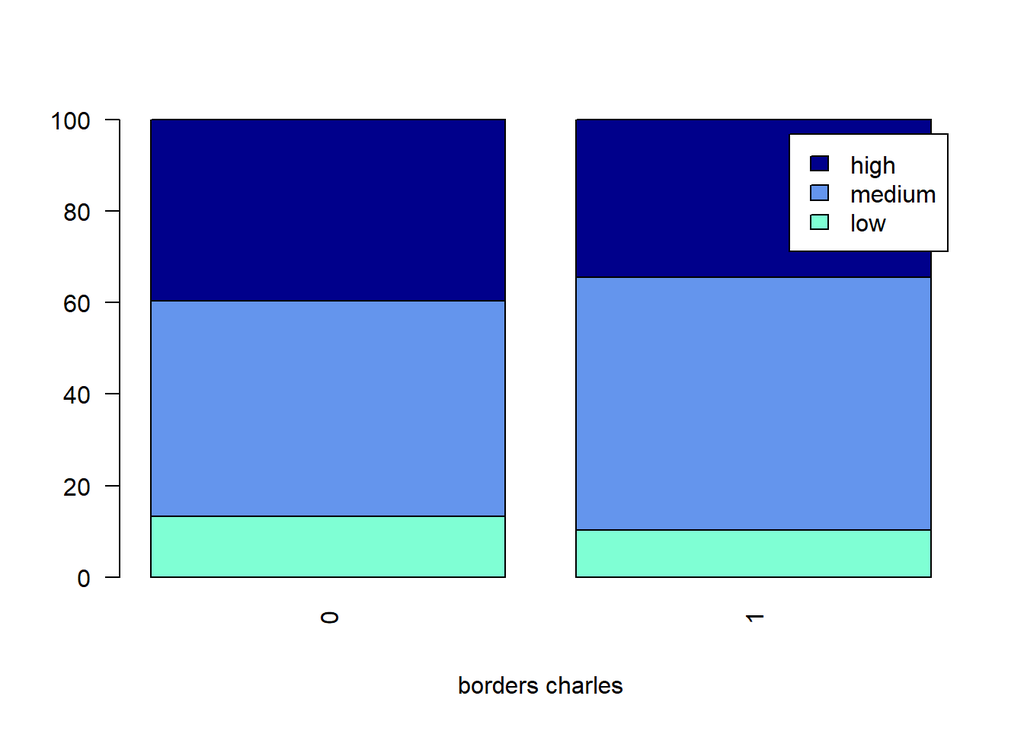

```r
barplot(t, col = c("aquamarine", "cornflowerblue", "darkblue"), xlab = "borders charles", legend=c("low", "medium", "high"), las=2)
```

#### 💪 Uppgift 2.3

Hur många procent av alla censusdistrikt ligger i angränsning till Charles River och tillhör en hög skattekategori? Hur stor andel av censusdistrikten med hög skatt ligger inte i angränsning till Charles River?

**Uppgift 2.3 - Svar**

Eftersom första frågan handlar om procentandelen av ALLA censusdistrikt, kan vi avläsa svaret i tabellen med tabellprocent. Vi ser att 2.1% av alla censusdistrikt ligger i angränsning till Charles River och tillhör en hög skattekategori

Andra frågan handlar om procentandelen betingat på skattekategori. Därför kan vi avläsa svaret i tabellen med kolumnprocent. Vi ser att 94.7% av censusdistrikten med hög skatt inte ligger i angränsning till Charles River.

```r
tally(~ cat_tax & borders_charles, data = Boston_census_data, margins = TRUE, format = "percent")
```

```
        borders_charles
cat_tax           0          1      Total
  Low     12.500000   0.625000  13.125000
  Medium  44.166667   3.333333  47.500000
  High    37.291667   2.083333  39.375000
  Total   93.958333   6.041667 100.000000
```

```r
tally(~ borders_charles | cat_tax, data = Boston_census_data, margins = TRUE, format = "percent")
```

```
               cat_tax
borders_charles        Low     Medium       High
          0      95.238095  92.982456  94.708995
          1       4.761905   7.017544   5.291005
          Total 100.000000 100.000000 100.000000
```

#### 💪 Uppgift 2.4

Vilka två variabler i datasetet `Boston_census_data` korrelerar mest med `tax_rate`? Beskriv det parvisa sambandet mellan `tax_rate` och vardera av dessa två variabler. Är dessa korrelationssamband eller kausala samband?

**Tips**

Kom ihåg att korrelation är ett beroendemått för *numeriska variabler*.

**Uppgift 2.4 - Svar**

Som förut tar vi bort alla icke-numeriska variabler och borders_charles. I tabellen kan vi avläsa att de två variablerna som korrelerar mest med tax_rate är:

- radial_acces (0.91)
- indust_p (0.72)

```r
strictly_numerical <- Boston_census_data %>%
  select_if(is.numeric) %>%
  select(-any_of(c("borders_charles")))

correlations <- cor(strictly_numerical)
sorted_crime_rate_correlations <- sort(correlations[,12])
sorted_crime_rate_correlations
```

```
  median_home_value         employ_dist         zoned_25k_p         n_rooms_avg
        -0.57896630         -0.52914953         -0.30041328         -0.27753095
           latitude           longitude pupil_teacher_ratio       before_1940_p
        -0.18885130          0.03146984          0.45499259          0.49875501
     lower_stat_pct          crime_rate                 NOx            indust_p
         0.57191334          0.58024439          0.66627269          0.71710407
      radial_access            tax_rate
         0.90994158          1.00000000
```

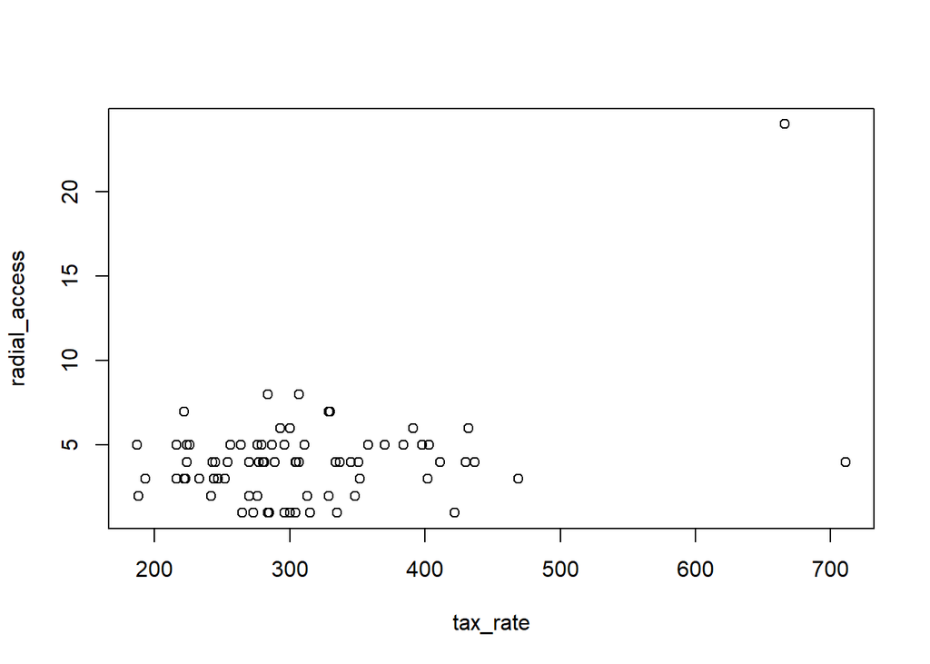

```r
plot(radial_access ~ tax_rate, data = Boston_census_data)
```

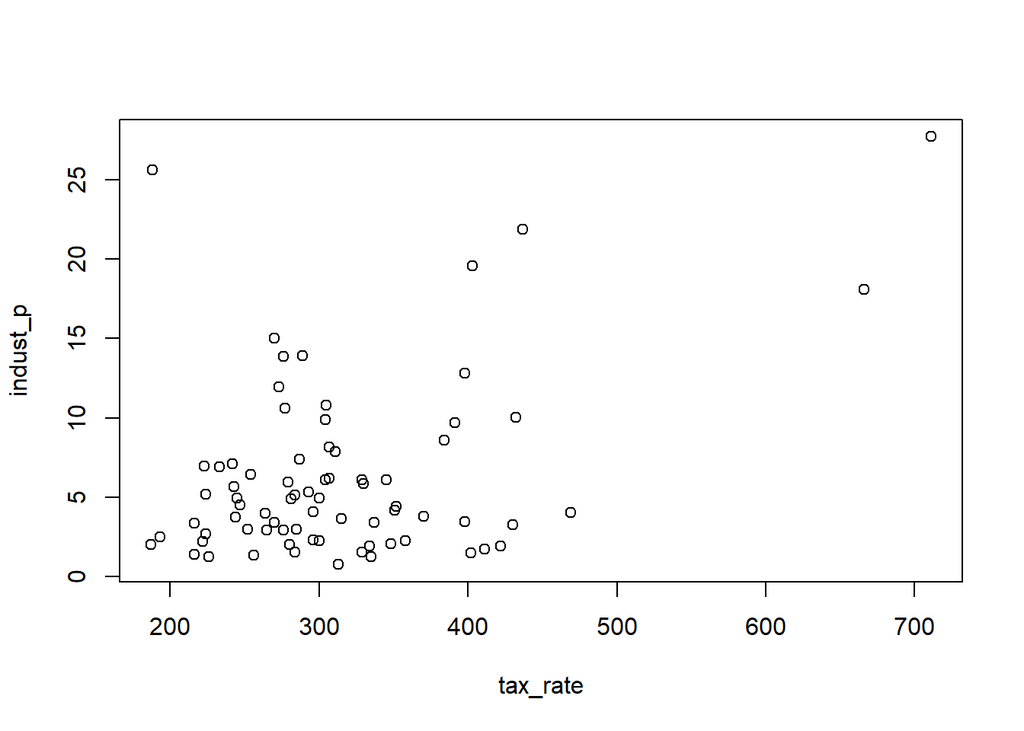

```r
plot(indust_p ~ tax_rate, data = Boston_census_data)
```

Vi kan inte genom enbart korrelation bevisa något kausalt samband i någon av dessa fall.

## 3. Avstånd till Fenway park

I detta avsnitt ska ni skapa en ny variabel som mäter avståndet till Fenway park (stadion där basebollslaget Boston Red Sox spelar sina hemmamatcher). Genom variablerna `latitude` och `longitude` kan vi beräkna det så kallade cirkelavståndet[^6] till Fenway park för varje distrikt. Formeln för cirkelavståndet är ganska komplicerad, men den finns implementerad i funktionen `distHaversine()` i R-paketet `geosphere`. Följande kod beräknar avståndet till Fenway park för varje censusdistrikt och sparar den som en ny variabel `dist_fenway_park` i `Boston_census_data`.

```r
library(geosphere) # Install if not available
lat_long <- cbind(Boston_census_data$latitude, Boston_census_data$longitude)
fenway_park_lat_long <- c(42.346462, -71.097250) # latitude and longitude for Fenway_park
Boston_census_data$dist_fenway_park <- distHaversine(lat_long, fenway_park_lat_long)
```

Vi kan visualisera Fenway park samt censusdistrikten i en interaktiv karta med hjälp av R-paketet `leaflet`. Följande kod visualiserar Fenway park samt censusdistrikten för observationerna 30 och 45.

```r
library(leaflet) # Install if not available
Boston_map <- leaflet() %>%
  addTiles() %>%
  addMarkers(lat = fenway_park_lat_long[1], lng = fenway_park_lat_long[2], popup="Fenway park") %>%
  addMarkers(lat = Boston_census_data$latitude[30], lng = Boston_census_data$longitude[30], popup="Observation 30") %>%
  addMarkers(lat = Boston_census_data$latitude[45], lng = Boston_census_data$longitude[45], popup="Observation 45")

Boston_map # Show interactive map
```

[interactive chart not shown]

#### 💪 Uppgift 3.1

Gör ett histogram för variabeln `dist_fenway_park`. Vilket av censusdistrikten har längst respektive kortast avstånd till Fenway park? Markera ut dessa distrikt i en interaktiv karta tillsammans med Fenway park.

**Tips**

När ni vet vad det längsta respektive kortaste avståndet är så kan ni använda `filter()` funktionen för att filtrera `Boston_census_data` på ett lämpligt sätt.

**Uppgift 3.1 - Svar**

Distriktet med kortast avstånd från Fenway Park är Wilmington, med en distans på 887 distanenheter.

Distriktet med längst avstånd från Fenway Park är Marshfield, med en distans på 33638 distansenheter.

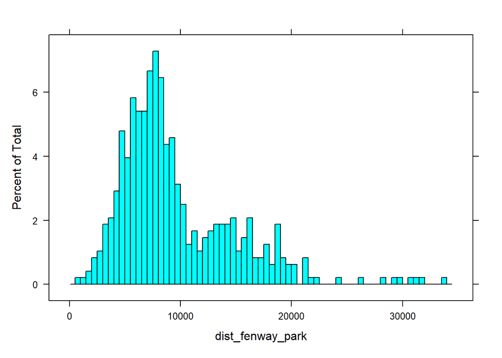

```r
library(geosphere) # Install if not available
lat_long <- cbind(Boston_census_data$latitude, Boston_census_data$longitude)
fenway_park_lat_long <- c(42.346462, -71.097250) # latitude and longitude for Fenway_park
Boston_census_data$dist_fenway_park <- distHaversine(lat_long, fenway_park_lat_long)

histogram(~ dist_fenway_park, data = Boston_census_data, breaks = 50)
```

```r
dist_fenway_park_min <- min(~ dist_fenway_park, data = Boston_census_data)
dist_fenway_park_max <- max(~ dist_fenway_park, data = Boston_census_data)
closest_district_to_fenway_park <- filter(Boston_census_data, dist_fenway_park == dist_fenway_park_min)
farthest_district_from_fenway_park <- filter(Boston_census_data, dist_fenway_park == dist_fenway_park_max)
#Distriktet med kortast avstånd = Wilmington med en distans på 887.
#Distriktet med längst avstånd = Marshfield med en distans på 33638.

#Draw interactive map
library(geosphere)
lat_long <- cbind(Boston_census_data$latitude, Boston_census_data$longitude)
fenway_park_lat_long <- c(42.346462, -71.097250) # latitude and longitude for Fenway_park
Boston_census_data$dist_fenway_park <- distHaversine(lat_long, fenway_park_lat_long)

library(leaflet)
Boston_map <- leaflet() %>%
  addTiles() %>%
  addMarkers(lat = fenway_park_lat_long[1], lng = fenway_park_lat_long[2], popup="Fenway park") %>%
  addMarkers(lat = closest_district_to_fenway_park$latitude[1], lng = closest_district_to_fenway_park$longitude[1], popup = closest_district_to_fenway_park$town) %>%
  addMarkers(lat = farthest_district_from_fenway_park$latitude[1], lng = farthest_district_from_fenway_park$longitude[1], popup = farthest_district_from_fenway_park$town)

Boston_map # Show interactive map
```

[interactive chart not shown]

#### 💪 Uppgift 3.2

Finns det ett samband mellan `dist_fenway_park` och `median_home_value`?

**Uppgift 3.2 - Svar**

Vi ser en mycket svag korrelation, med styrkan -0.002. Plotten visar inte heller något samband, så vi kan med ganska god säkerhet säga att det inte finns något meningsfullt samband mellan de två variablerna, annat än att variationen på median home value tycks vara större närmare Fenway Park.

```r
cor(Boston_census_data$median_home_value, Boston_census_data$dist_fenway_park)
```

```
[1] -0.002774624
```

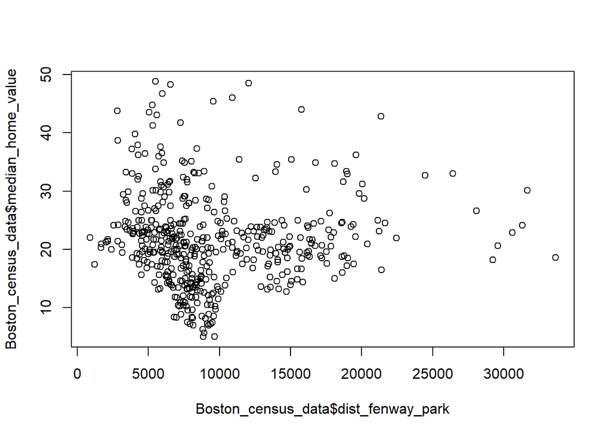

```r
plot(Boston_census_data$dist_fenway_park, Boston_census_data$median_home_value)
```

#### 💪 Uppgift 3.3

Finns det ett samband mellan `dist_fenway_park` och `crime_rate`?

**Uppgift 3.3 - Svar**

Det finns en negativ korrelation med en styrka på ca -0.1228. Då brottslighet är mycket låg i majoritet av distrikten är plotten däremot svår att avläsa: i de allra flesta fall begås nästan inga brott alls. Däremot verkar alla distrikt med en brottslighet > ca 3 ligga mellan 5000-10 000 distansenheter från fenway park. Det finns alltså ett mycket tydligt samband som ej reflekteras i korrelationskoficienten.

```r
cor(Boston_census_data$crime_rate, Boston_census_data$dist_fenway_park)
```

```
[1] -0.1228651
```

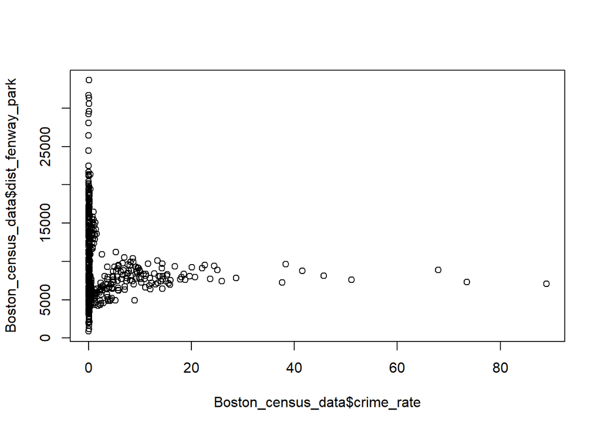

```r
plot(Boston_census_data$crime_rate, Boston_census_data$dist_fenway_park)
```

## 4. Enkel linjär regression

I detta avsnitt ska ni anpassa och tolka några enkla linjära regressionsmodeller.

#### 💪 Uppgift 4.1

Anpassa en linjär regression med responsvariabel `NOx` och förklarande variabel `employ_dist`. Rita den anpassade regressionslinjen tillsammans med data i en lämplig figur. Beskriv resultaten och tolka modellen. Utför en modellvalidering via en residualanalys och kommentera modellens lämplighet. Om modellen inte anses lämplig, vilka antaganden har inte varit uppfyllda?

**Uppgift 4.1 - Svar**

Punktdiagrammet visar ett negativ, icke-linjärt samband mellan NOx och employ_dist. Regressionslinjen ser inte ut att passa så bra, eftersom den är rak, och sambandet inte är linjärt.

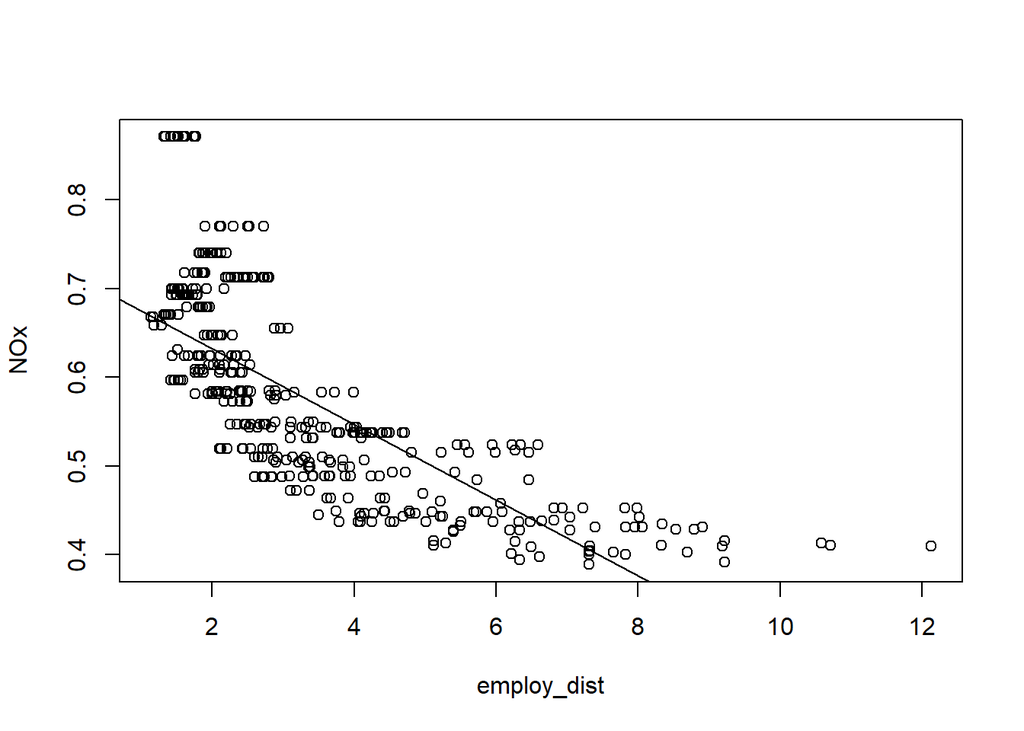

```r
fit <- lm(NOx ~ employ_dist, data = Boston_census_data)
plot(NOx ~ employ_dist, data = Boston_census_data)
abline(fit)
```

Residualanalysen bekräftar våra farhågor om den linjära regressionens lämplighet. Normal Q-Q plotten visar att de standardiserade residualern inte följer en rak linje med 45 graders vinkel. Detta är ett tecken på att modellen inte är väl anpassad, eftersom residualerna inte är normalfördelade.

I Residuals vs Fitted syns ett (icke linjärt) samband mellan residualerna och fitted values. Detta är ett tecken på att sambandet mellan NOx och employ_dist inte är linjärt. Dessutom uppvisar den heteroscedasticitet, dvs att residualerna blir större längre åt höger.

Överlag är det en dålig modell, för ingen av antagandena verkar vara uppfyllda.

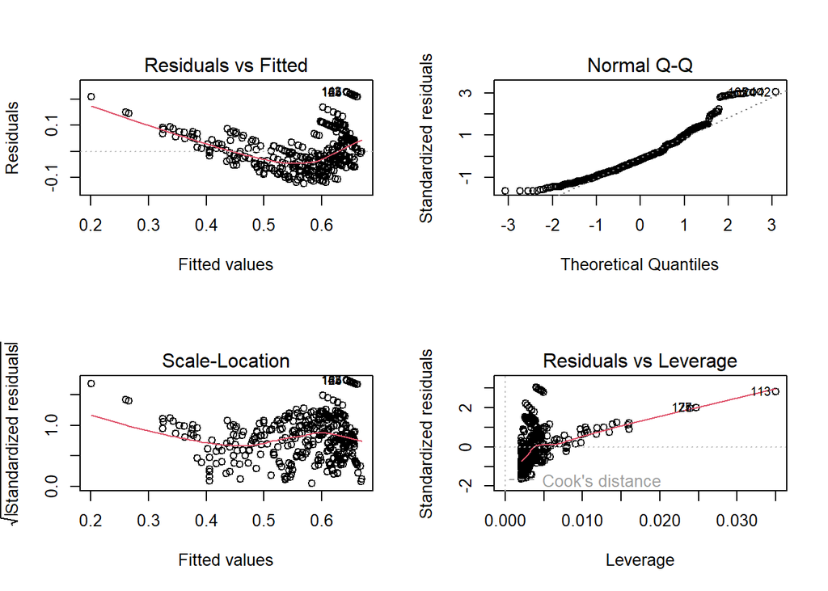

```r
par(mfrow = c(2, 2))
plot(fit)
```

```r
par(mfrow = c(1, 1))
```

#### 💪 Uppgift 4.2

Använd modellen i Uppgift 4.1 för att prediktera genomsnittsutsläppet för observation 10 med `employ_dist`=10.5857 och beräkna dess residual.

**Uppgift 4.2 - Svar**

Det predikterade värdet för employ_dist = 10.5857 är 0.266 NOx.

Det observerade värdet är 0.413 NOx.

```r
new_x <- data.frame(employ_dist = c(Boston_census_data[10,12]))
predicted <- predict(fit, newdata = new_x)
predicted
```

```
        1
0.2662308
```

```r
observed <- Boston_census_data[10,9]
residual <- predicted - observed
residual
```

```
         1
-0.1467692
```

#### 💪 Uppgift 4.3

Använd Tukeys cirkel för att transformera variablerna i Uppgift 4.1 (avgör själv vilken eller vilka av de två som behöver transformeras). Anpassa en ny linjär regression på de transformerade data. Utför en modellvalidering (efter transformation) via en residualanalys och kommentera modellens lämplighet jämfört med modellen i Uppgift 4.1. Plotta den anpassade regressionen i icke-transformerad skala tillsammans med data (också i icke-transformerad skala) i en lämplig figur.

**Tips**

Tänk på att ta hänsyn till eventuella transformationer!

**Uppgift 4.3 - Svar**

Vi är i nedre vänstra hörnet på tukeys cirkel och kan därför gå neråt i trappan med antingen x eller y eller med både x och y. Vi gör följande två transformationer:

$$x \Rightarrow \sqrt{x}$$

$$y \Rightarrow -y^{-\frac{1}{2}}$$

Och får en scatterplot som visar ett rakare samband.

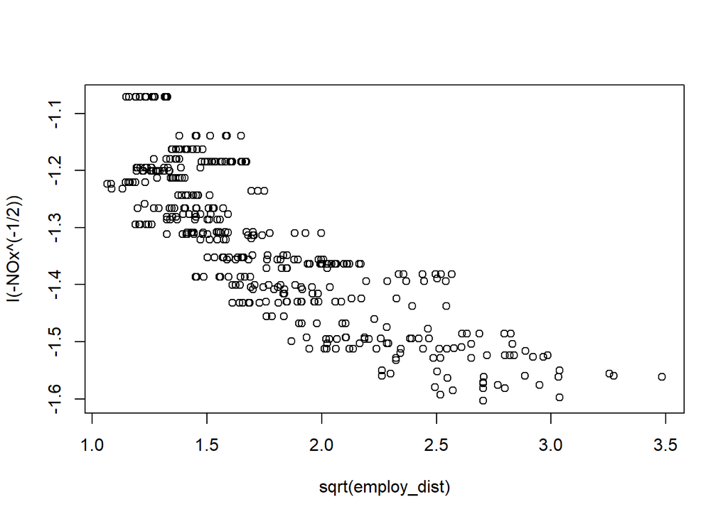

```r
fit2 <- lm(I(-NOx^(-1/2)) ~ sqrt(employ_dist), data = Boston_census_data)

plot(I(-NOx^(-1/2)) ~ sqrt(employ_dist), data = Boston_census_data)
```

```r
#/
transformed_y_hat <- predict(fit2) # transformed scale prediction
y_hat <- ((transformed_y_hat * -1)^(-1/2))^2 #original scale prediction
head(transformed_y_hat)
```

```
        1         2         3         4         5         6
-1.254477 -1.433188 -1.217371 -1.273179 -1.294556 -1.457072
```

```r
head(y_hat)
```

```
        1         2         3         4         5         6
0.7971451 0.6977450 0.8214421 0.7854357 0.7724656 0.6863079
```

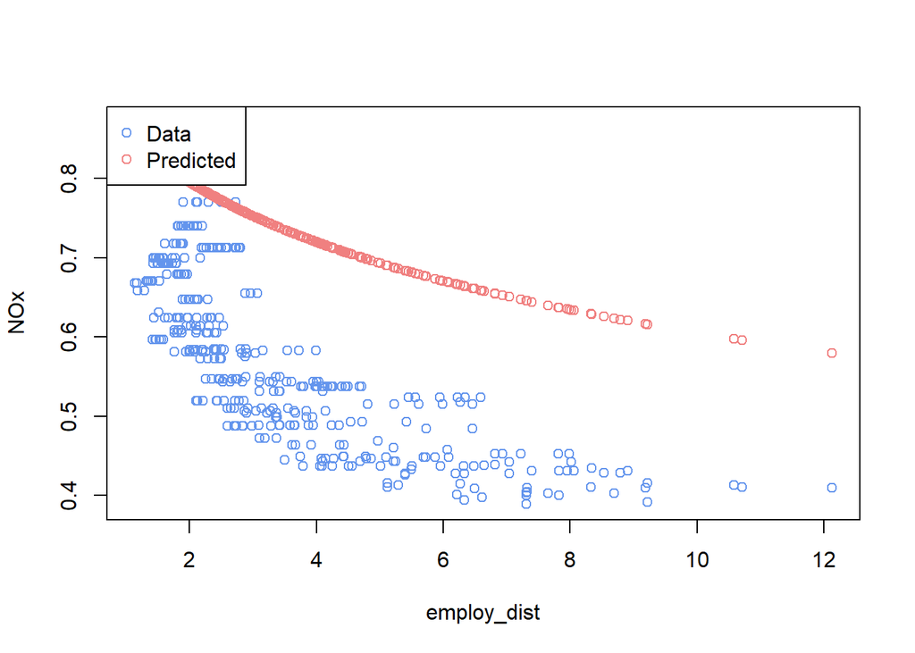

```r
plot(NOx ~ employ_dist, data = Boston_census_data, col = "cornflowerblue")# Data on original scale
lines(Boston_census_data$employ_dist, y_hat, type = "p", col = "lightcoral")
legend(x = "topleft", pch = c(1, 1), col = c("cornflowerblue", "lightcoral"), legend=c("Data", "Predicted"))
```

Residualerna visar en förbättring, men det är ännu inte perfekt. Normal Q-Q plotten följer den diagonala raka linjen något bättre, men de standardiserade residualerna är fortfarande för höga för höga och låga värden.

Vi ser att modellen inte gör ett bra jobb med att predicera data när vi jämför den emot data i originalskala.

# residual vs. fitted visar endast ett svagt icke-linjärt samband, som är bättre än tidigare.

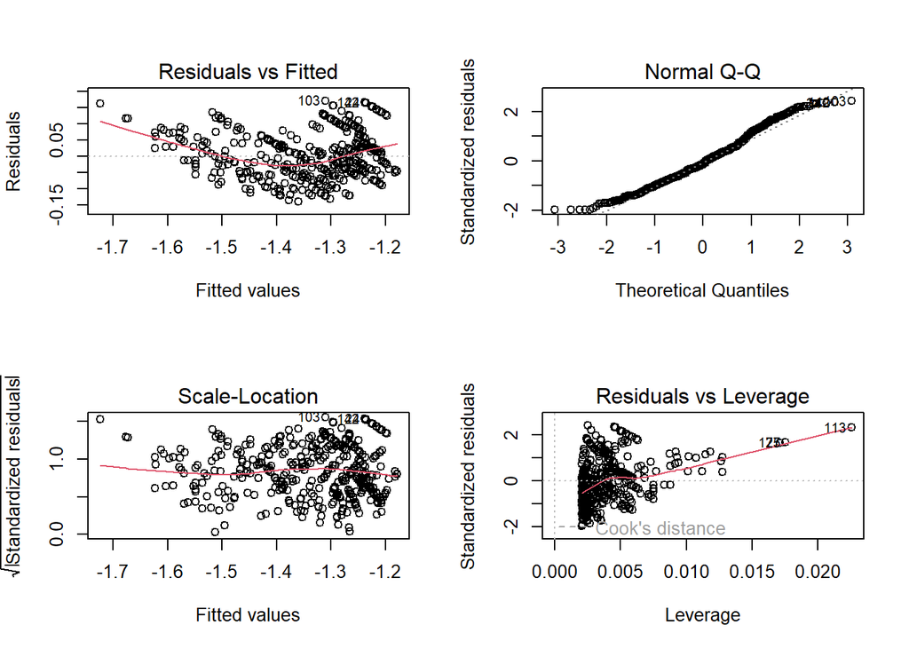

```r
par(mfrow = c(2, 2))
plot(fit2)
```

```r
par(mfrow = c(1, 1))
```

#### 💪 Uppgift 4.4

Använd modellen i Uppgift 4.3 för att prediktera genomsnittsutsläppet för observation 10 med `employ_dist`=10.5857 och beräkna dess residual. Kommentera resultaten jämfört med Uppgift 4.2.

**Tips**

Tänk på att ta hänsyn till eventuella transformationer!

**Uppgift 4.4 - Svar**

Residualen för modellen i 4.3 är ca 0.1848. För modellen i Uppgift 2 är residualen -0.147. Modellen i uppgift 4.2 kom alltså närmare en modellen i uppgift 4.3

```r
NOx_hat_transformed <- predict(fit2,newdata = data.frame(employ_dist = 10.5857))
NOx_hat <- (1/sqrt(NOx_hat_transformed * -1))^2
residual <- NOx_hat - Boston_census_data[10, 9]
residual
```

```
        1
0.1848759
```

## 5. Multipel linjär regression

I detta avsnitt ska ni studera multipel linjära regression.

#### 💪 Uppgift 5.1

Anpassa en linjär regression med responsvariabel logaritmerad `median_home_value` samt förklarande variabler `lower_stat_pct` och dummy-variabeln `borders_charles`. Tolka koefficienten för `borders_charles`.

**Uppgift 5.1 - Svar**

```r
median_home_model <- lm(log(median_home_value) ~ lower_stat_pct + borders_charles, data = Boston_census_data)
summary(median_home_model)
```

```
Call:
lm(formula = log(median_home_value) ~ lower_stat_pct + borders_charles,
    data = Boston_census_data)

Residuals:
     Min       1Q   Median       3Q      Max
-0.94794 -0.12591 -0.01925  0.11351  0.89520

Coefficients:
                 Estimate Std. Error t value Pr(>|t|)
(Intercept)      3.561555   0.021210 167.916  < 2e-16 ***
lower_stat_pct  -0.043698   0.001426 -30.637  < 2e-16 ***
borders_charles  0.134560   0.042267   3.184  0.00155 **
---
Signif. codes:  0 '***' 0.001 '**' 0.01 '*' 0.05 '.' 0.1 ' ' 1

Residual standard error: 0.2206 on 477 degrees of freedom
Multiple R-squared:  0.6658,    Adjusted R-squared:  0.6644
F-statistic: 475.1 on 2 and 477 DF,  p-value: < 2.2e-16
```

Koefficienten för borders_charles, ger oss värdet 0.134560. Värdet av det predicerade medianpriset för ett hus, givet att `lower_stat_pct` är konstant, bör öka med ca 13.45% om huset ligger i ett distrikt som angränsar Charles.

#### 💪 Uppgift 5.2

Anpassa en linjär regression med responsvariabel `NOx` samt förklarande variabler `lower_stat_pct` och dummy-variabeln `borders_charles`. Vad tror ni om den statistiska signifikansen för respektive förklarande variabel?

**Uppgift 5.2 - Svar**

```r
NOx_Model <- lm(NOx ~ lower_stat_pct + borders_charles, data = Boston_census_data)
summary(NOx_Model)
```

```
Call:
lm(formula = NOx ~ lower_stat_pct + borders_charles, data = Boston_census_data)

Residuals:
     Min       1Q   Median       3Q      Max
-0.28697 -0.05925 -0.01527  0.04650  0.37454

Coefficients:
                 Estimate Std. Error t value Pr(>|t|)
(Intercept)     0.4212071  0.0088203  47.754   <2e-16 ***
lower_stat_pct  0.0101837  0.0005931  17.169   <2e-16 ***
borders_charles 0.0431425  0.0175768   2.455   0.0145 *
---
Signif. codes:  0 '***' 0.001 '**' 0.01 '*' 0.05 '.' 0.1 ' ' 1

Residual standard error: 0.09175 on 477 degrees of freedom
Multiple R-squared:  0.3862,    Adjusted R-squared:  0.3837
F-statistic: 150.1 on 2 and 477 DF,  p-value: < 2.2e-16
```

För variabeln lower_stat_pct är den statistiska signifikansen <2e-16, vilket är mycket lågt. Oddsen att det handlar om slumpen och inte ett faktiskt samband är mycket lågt.

För variabeln borders_charles är den statistiska signifikansen 0.0145, vilket är högre. Oddsen att det handlar om slumpen och inte ett faktiskt samband är ca 1.45%, vilket är ganska högt beroende på sammanhanget. Däremot tror vi att resultatet fortfarande är statistiskt signifikant.

#### 💪 Uppgift 5.3

Använd modellen i Uppgift 5.1 för att prediktera `median_home_value` för observation 30 och beräkna dess residual.

**Tips**

Tänk på att ta hänsyn till log-transformationen i den anpassade modellen!

**Uppgift 5.3 - Svar**

```r
observation_30 <- data.frame(Boston_census_data[30, ])
observation_30_hat <- predict(median_home_model, observation_30)
exp(observation_30_hat)
```

```
      30
24.61193
```

#### 💪 Uppgift 5.4

Ni ska nu utveckla en prognosmodell för medianhuspriset `median_home_value`. Ni får endast välja mellan följande förklarande variabler samt godtyckliga transformationer av dom (ni får även transformera responsen):

- `before_1940_p`
- `crime_rate`
- `radial_access`
- `NOx`
- `dist_fenway_park` (som skapades i Avsnitt 3).

Det finns $2^5 = 32$ olika sätt att inkludera de olika förklarande variabler och därmed 32 olika modeller man kan testa, plus i princip hur många som helst om vi också transformerar. Vi förväntar oss naturligtvis inte att ni går igenom varje möjlig modell, men vi förutsätter att ni testar er fram metodiskt.

För att utvärdera mellan olika modeller kan ni använda justerat R-kvadrat samt korsvalidering med 4 folds. **Sortera inte ``boston_census_data.Rdata` slumpmässigt när ni korsvaliderar (data ligger redan i slumpmässig ordning)**. Dela upp datasetet i fyra delar när ni korsvaliderar (del 1: observationer 1-120, del 2: observationer 121-240, del 3: observationer 241-360, del 4: observationer 361-480).

**Tips**

Tänk på att ta hänsyn till eventuell transformation av responsvariabeln när ni utför korsvalideringen. Korsvalideringen använder prediktionen $\hat{y}$ som är prediktionen av $y$. Exempelvis, om ni har valt transformationen $\log(y)$ är modellens prediktion av responsen $\widehat{\log(y)}$. När ni korsvaliderar blir då $\hat{y}=\exp\left(\widehat{\log(y)}\right)$ prediktionen av $y$.

Om ni använder `reg_crossval()` funktionen från kurspaketet `sdakurs` tänk då på två saker:

- Använd argumentet `obs_order = 1:480` för att inte sortera data slumpmässigt.
- Funktionen kan inte hantera en transformerad respons.

Vill man transformera responsen kan man följa korsvalideringsexemplet (med transformerad respons) i Lab 4.

**Uppgift 5.4 - Svar**

Vi plottar först de olika förklarande variablerna emot median_home_value för att se hur lämpliga de enskilda distributionerna var att använda till en linjär regression. Vi kollade om de var linjära nog.

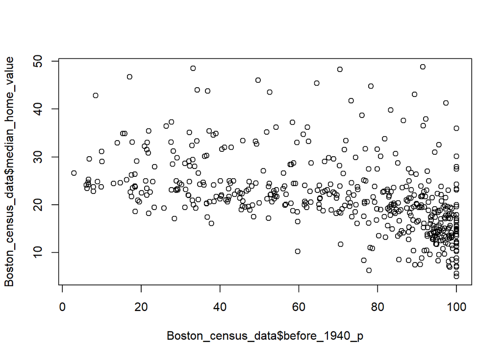

```r
plot(Boston_census_data$before_1940_p, Boston_census_data$median_home_value)
```

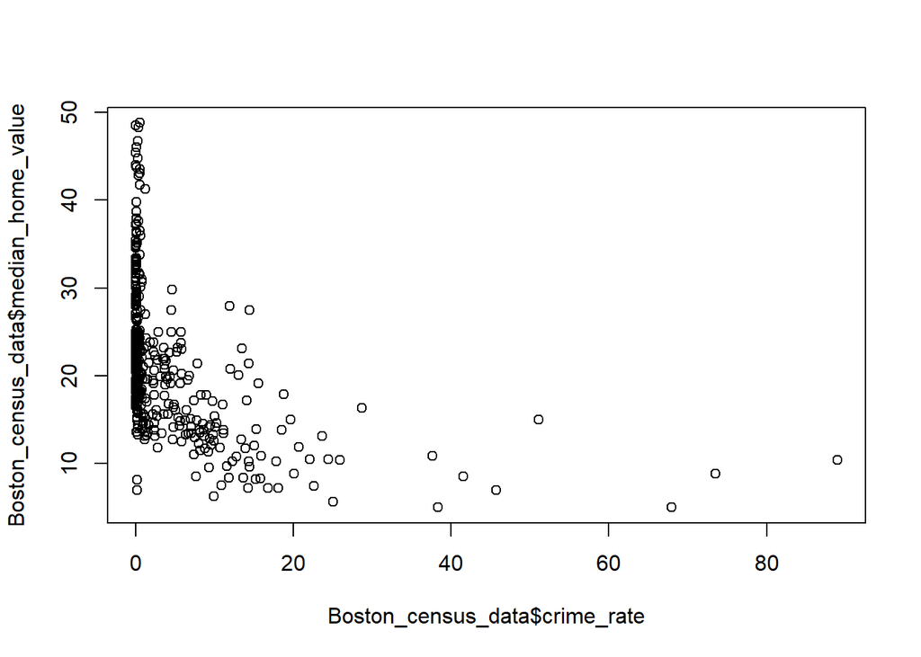

```r
plot(Boston_census_data$crime_rate, Boston_census_data$median_home_value)
```

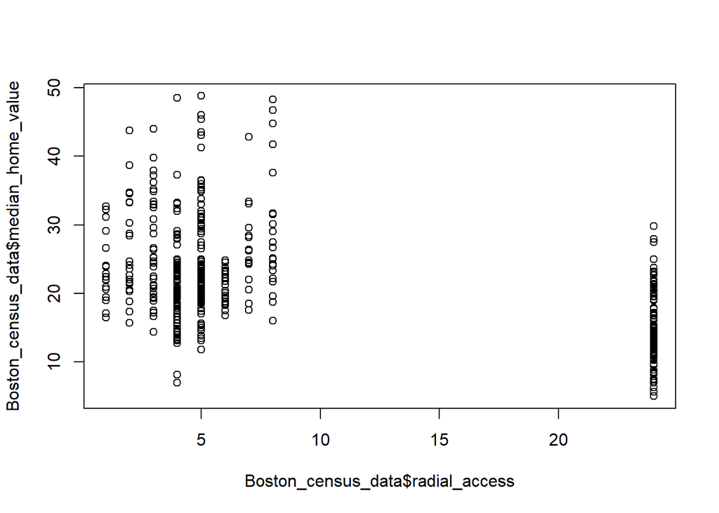

```r
plot(Boston_census_data$radial_access, Boston_census_data$median_home_value)
```

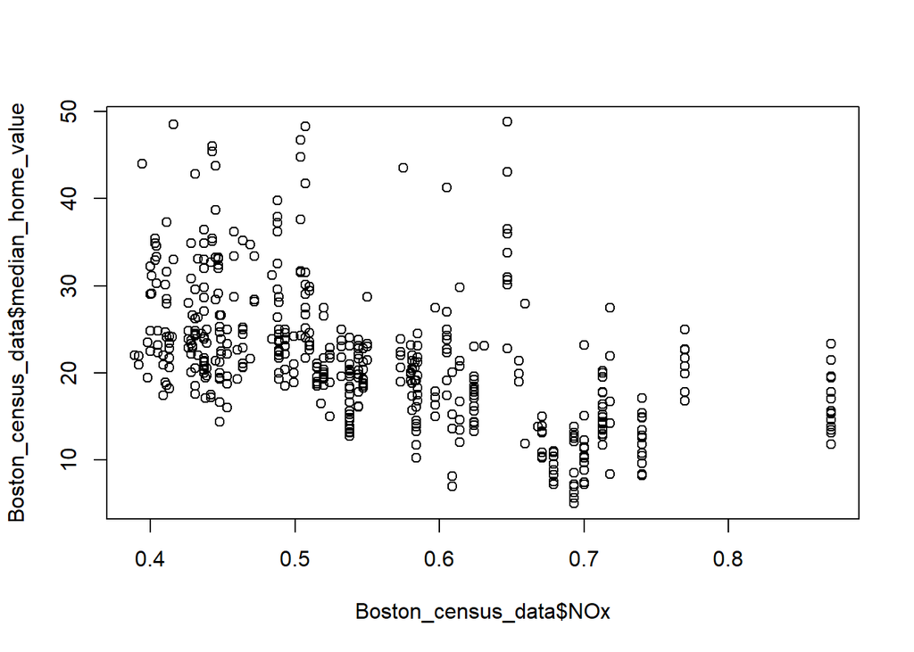

```r
plot(Boston_census_data$NOx, Boston_census_data$median_home_value)
```

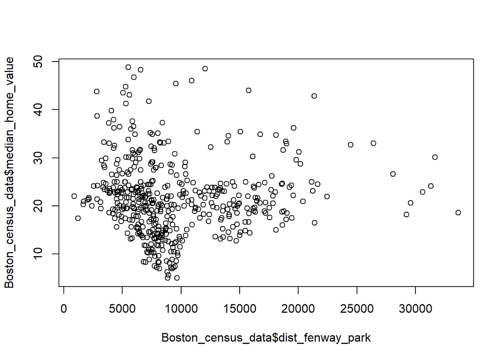

```r
plot(Boston_census_data$dist_fenway_park, Boston_census_data$median_home_value)
```

```r
multipleModel <- lm(median_home_value ~ crime_rate + before_1940_p+ NOx + dist_fenway_park, data = Boston_census_data)
summary(multipleModel)
```

```
Call:
lm(formula = median_home_value ~ crime_rate + before_1940_p +
    NOx + dist_fenway_park, data = Boston_census_data)

Residuals:
    Min      1Q  Median      3Q     Max
-12.724  -3.690  -1.316   2.408  28.598

Coefficients:
                   Estimate Std. Error t value Pr(>|t|)
(Intercept)       4.151e+01  1.768e+00  23.476  < 2e-16 ***
crime_rate       -2.352e-01  3.507e-02  -6.706 5.69e-11 ***
before_1940_p    -6.365e-02  1.452e-02  -4.384 1.43e-05 ***
NOx              -2.110e+01  3.618e+00  -5.833 1.01e-08 ***
dist_fenway_park -3.101e-04  5.666e-05  -5.474 7.15e-08 ***
---
Signif. codes:  0 '***' 0.001 '**' 0.01 '*' 0.05 '.' 0.1 ' ' 1

Residual standard error: 6.086 on 475 degrees of freedom
Multiple R-squared:  0.3965,    Adjusted R-squared:  0.3914
F-statistic: 78.02 on 4 and 475 DF,  p-value: < 2.2e-16
```

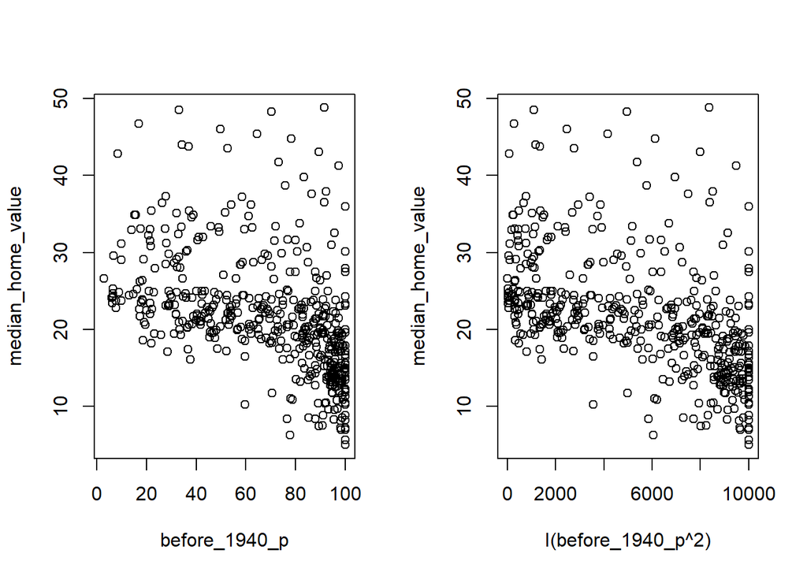

```r
par(mfrow = c(1, 2))
plot(median_home_value ~ before_1940_p, data = Boston_census_data)
plot(median_home_value ~ I(before_1940_p^2), data = Boston_census_data)
```

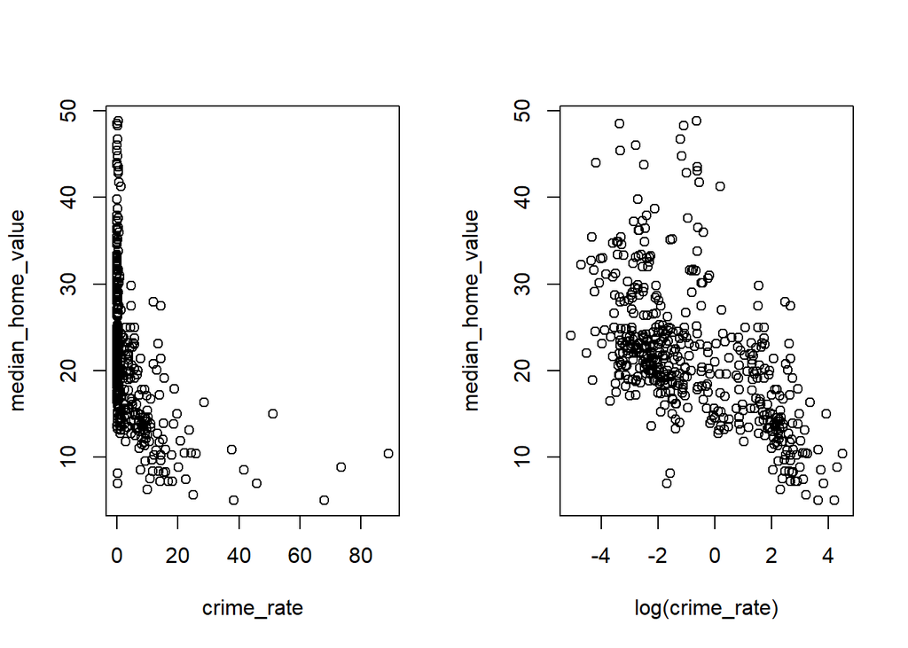

```r
par(mfrow = c(1, 1))

par(mfrow = c(1, 2))
plot(median_home_value ~ crime_rate, data = Boston_census_data)
plot(median_home_value ~ log(crime_rate), data = Boston_census_data)
```

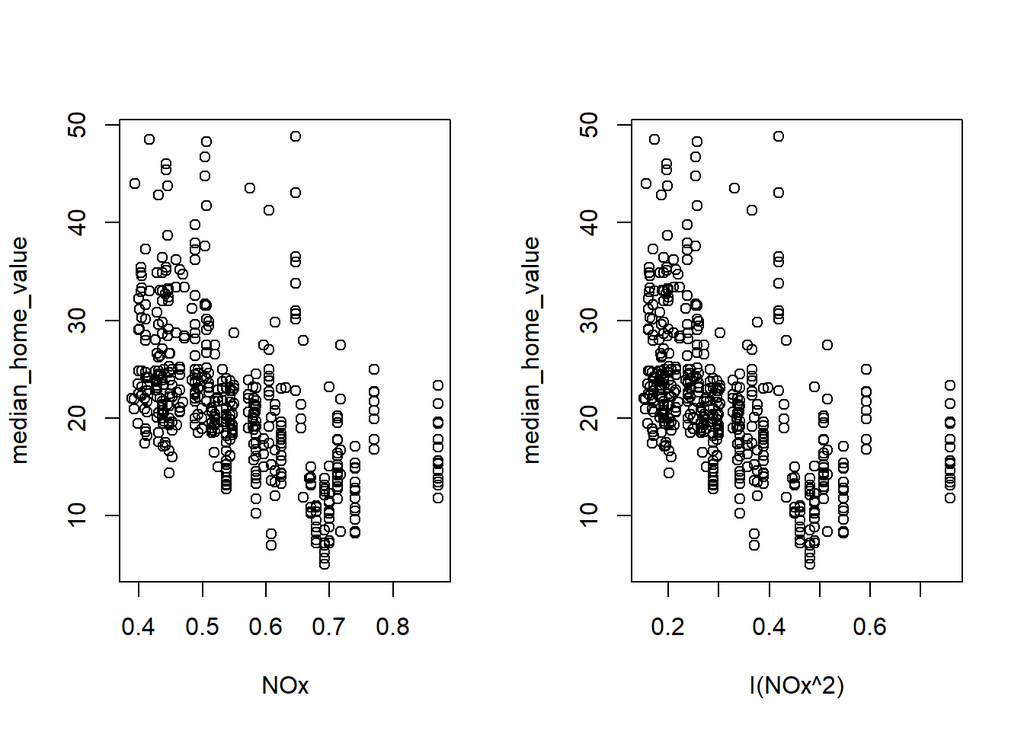

```r
par(mfrow = c(1, 1))

par(mfrow = c(1, 2))
plot(median_home_value ~ NOx, data = Boston_census_data)
plot(median_home_value ~ I(NOx^2), data = Boston_census_data) #original is better
```

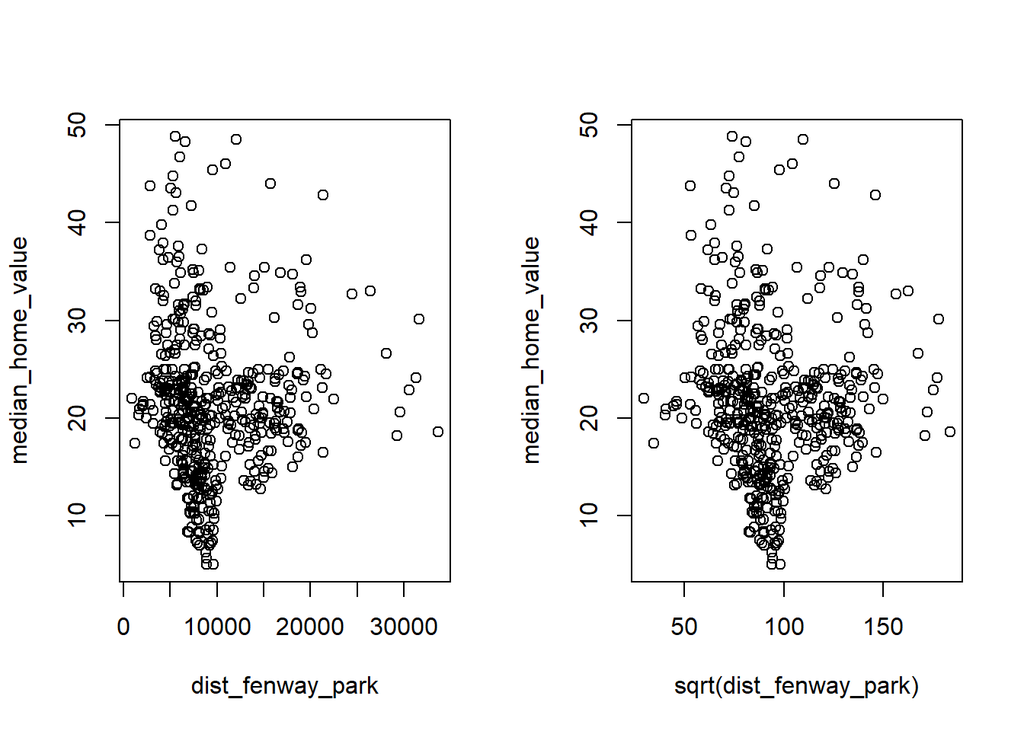

```r
par(mfrow = c(1, 1))

par(mfrow = c(1, 2))
plot(median_home_value ~ dist_fenway_park, data = Boston_census_data)
plot(median_home_value ~ sqrt(dist_fenway_park), data = Boston_census_data) #original is same
```

```r
par(mfrow = c(1, 1))
```

```r
multipleModel2 <- lm(median_home_value ~ I(before_1940_p^2) + log(crime_rate) + NOx + dist_fenway_park, data = Boston_census_data)
summary(multipleModel2)
```

```
Call:
lm(formula = median_home_value ~ I(before_1940_p^2) + log(crime_rate) +
    NOx + dist_fenway_park, data = Boston_census_data)

Residuals:
    Min      1Q  Median      3Q     Max
-13.468  -3.828  -1.377   2.582  28.196

Coefficients:
                     Estimate Std. Error t value Pr(>|t|)
(Intercept)         3.100e+01  2.436e+00  12.724  < 2e-16 ***
I(before_1940_p^2) -5.116e-04  1.252e-04  -4.085 5.17e-05 ***
log(crime_rate)    -1.433e+00  2.110e-01  -6.794 3.27e-11 ***
NOx                -7.999e+00  4.344e+00  -1.841   0.0662 .
dist_fenway_park   -3.409e-04  5.625e-05  -6.060 2.77e-09 ***
---
Signif. codes:  0 '***' 0.001 '**' 0.01 '*' 0.05 '.' 0.1 ' ' 1

Residual standard error: 6.036 on 475 degrees of freedom
Multiple R-squared:  0.4063,    Adjusted R-squared:  0.4013
F-statistic: 81.27 on 4 and 475 DF,  p-value: < 2.2e-16
```

```r
#Crossvalidation for our non-transformed model

n <- 480 # Number of observations
# Fold 1:
obs_index <- c(1:n) # Keeps track of the indices of  the dataset (1, 2, 3, ...., n = 125)
test_fold_index <- obs_index[c(1:120)] # Subsets indices 1:25 (test data fold 1)
training_fold_index <- obs_index[-c(1:120)] # Takes out the complement
lm_modell1_fold1 <- lm(median_home_value ~ before_1940_p + crime_rate + NOx + dist_fenway_park, subset = training_fold_index, data = Boston_census_data) # Estimate fold 1
test_data <- Boston_census_data[test_fold_index, ] # Create test data for fold
y_hat_fold1 <- predict(lm_modell1_fold1, newdata = test_data) # Predict test data in sqrt scale
SSE_fold1 <- sum((test_data$median_home_value - y_hat_fold1)^2)

# Fold 2:
test_fold_index <- obs_index[c(121:240)]
training_fold_index <- obs_index[-c(121:240)]
lm_modell1_fold2 <- lm(median_home_value ~ before_1940_p + crime_rate + NOx + dist_fenway_park, subset = training_fold_index, data = Boston_census_data)
test_data <- Boston_census_data[test_fold_index, ]
y_hat_fold2 <- predict(lm_modell1_fold2, newdata = test_data)
SSE_fold2 <- sum((test_data$median_home_value - y_hat_fold2)^2)

# Fold 3:
test_fold_index <- obs_index[c(241:360)]
training_fold_index <- obs_index[-c(241:360)]
lm_modell1_fold3 <- lm(median_home_value ~ before_1940_p + crime_rate + NOx + dist_fenway_park, subset = training_fold_index, data = Boston_census_data)
test_data <- Boston_census_data[test_fold_index, ]
y_hat_fold3 <- predict(lm_modell1_fold3, newdata = test_data)
SSE_fold3 <- sum((test_data$median_home_value - y_hat_fold3)^2)

# Fold 4:
test_fold_index <- obs_index[c(241:360)]
training_fold_index <- obs_index[-c(361:480)]
lm_modell1_fold4 <- lm(median_home_value ~ before_1940_p + crime_rate + NOx + dist_fenway_park, subset = training_fold_index, data = Boston_census_data)
test_data <- Boston_census_data[test_fold_index, ]
y_hat_fold4 <- predict(lm_modell1_fold4, newdata = test_data)
SSE_fold4 <- sum((test_data$median_home_value - y_hat_fold4)^2)


#Crossvalidation for the model without transformations
n <- 480 # Number of observations
# Fold 1:
obs_index <- c(1:n) # Keeps track of the indices of  the dataset (1, 2, 3, ...., n = 125)
test_fold_index <- obs_index[c(1:120)] # Subsets indices 1:25 (test data fold 1)
training_fold_index <- obs_index[-c(1:120)] # Takes out the complement
lm_modell1_fold1 <- lm(median_home_value ~ I(before_1940_p) + log(crime_rate) + NOx + dist_fenway_park, subset = training_fold_index, data = Boston_census_data) # Estimate fold 1
test_data <- Boston_census_data[test_fold_index, ] # Create test data for fold
y_hat_fold1 <- predict(lm_modell1_fold1, newdata = test_data) # Predict test data in sqrt scale
SSE_fold1_transformed <- sum((test_data$median_home_value - y_hat_fold1)^2)

# Fold 2:
test_fold_index <- obs_index[c(121:240)]
training_fold_index <- obs_index[-c(121:240)]
lm_modell1_fold2 <- lm(median_home_value ~ I(before_1940_p^2) + log(crime_rate) + NOx + dist_fenway_park, subset = training_fold_index, data = Boston_census_data)
test_data <- Boston_census_data[test_fold_index, ]
y_hat_fold2 <- predict(lm_modell1_fold2, newdata = test_data)
SSE_fold2_transformed <- sum((test_data$median_home_value - y_hat_fold2)^2)

# Fold 3:
test_fold_index <- obs_index[c(241:360)]
training_fold_index <- obs_index[-c(241:360)]
lm_modell1_fold3 <- lm(median_home_value ~ I(before_1940_p^2) + log(crime_rate) + NOx + dist_fenway_park, subset = training_fold_index, data = Boston_census_data)
test_data <- Boston_census_data[test_fold_index, ]
y_hat_fold3 <- predict(lm_modell1_fold3, newdata = test_data)
SSE_fold3_transformed <- sum((test_data$median_home_value - y_hat_fold3)^2)

# Fold 4:
test_fold_index <- obs_index[c(241:360)]
training_fold_index <- obs_index[-c(361:480)]
lm_modell1_fold4 <- lm(median_home_value ~ I(before_1940_p^2) + log(crime_rate) + NOx + dist_fenway_park, subset = training_fold_index, data = Boston_census_data)
test_data <- Boston_census_data[test_fold_index, ]
y_hat_fold4 <- predict(lm_modell1_fold4, newdata = test_data)
SSE_fold4_transformed <- sum((test_data$median_home_value - y_hat_fold4)^2)


#RMSE
sqrt((1/n) * (sum(SSE_fold1, SSE_fold2, SSE_fold3, SSE_fold4)))
```

```
[1] 5.655712
```

```r
sqrt((1/n) * (sum(SSE_fold1_transformed, SSE_fold2_transformed, SSE_fold3_transformed, SSE_fold4_transformed)))
```

```
[1] 5.567281
```

Vi såg också en liten förbättring i RMSE, från 5.6556 till 5.567. Våran modell är alltså lite bättre än om vi enbart hade haft alla värden i originalskala.

💪 Uppgift 5.5

Gör en residualanalys av den valda modellen i Uppgift 5.3.

**Uppgift 5.5 - Svar**

```r
resid <- residuals(multipleModel2)
head(resid)
```

```
         1          2          3          4          5          6
-3.9728609 -4.8563058 -1.7768881 -2.8944773 -0.2715414 -7.7499708
```

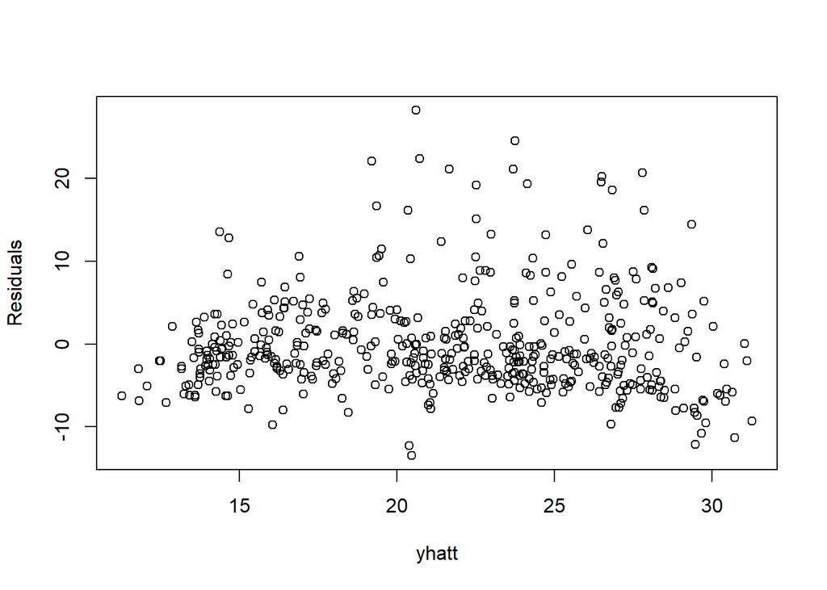

```r
plot(multipleModel2$fitted.values, resid, xlab = "yhatt", ylab = "Residuals")
```

Vi ser att när vi plottar residualer mot yhatt ser vi en viss kon-form, vilket inte är optimalt, eftersom det tyder på att variansen inte är konstant. Vi ser inte heller något tydligt samband uppstå mellan residualerna och det predicerade värdet, vilket är ett gott tecken. Det ser alltså helt okej ut att fortsätta som vi gjort med att förbättra modellen härifrån.

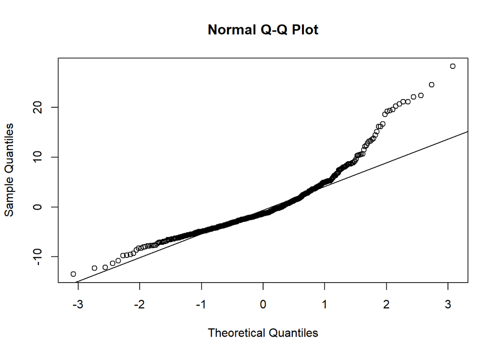

```r
qqnorm(resid)
qqline(resid)
```

Vi ser på våran qqplot att den är hyfsat linjär, och ser bra ut mellan -1 och 1. Därefter blir den snabbt mycket sämre därefter. Vi hittade inget sätt att fixa detta på,

#### 💪 Uppgift 5.6

Använd modellen i Uppgift 5.4 för att prediktera medianhuspriset för observationerna i datasetet `Boston_districts_to_predict.RData`. Skriv ut resultatet så att vi enkelt kan jämföra dina prognoser när vi rättar.

**Tips**

Tänk på att ta hänsyn till eventuella transformationer av de förklarande variablerna! Om ni har `dist_fenway_park` med i er prognosmodell behöver ni räkna ut dess värde för observationerna i datasetet `Boston_districts_to_predict.RData` (genom att använda latitud och longitud variablerna såsom i Avsnitt 3).

**Uppgift 5.6 - Svar**

```r
#Fix Boston_districts_to_predict
lat_long <- cbind(Boston_districts_to_predict$latitude, Boston_districts_to_predict$longitude)
fenway_park_lat_long <- c(42.346462, -71.097250) # latitude and longitude for Fenway_park
Boston_districts_to_predict$dist_fenway_park <- distHaversine(lat_long, fenway_park_lat_long)

prediction <- predict(multipleModel2, Boston_districts_to_predict)
data.frame(prediction)
```

```
   prediction
1    28.37849
2    16.45280
3    31.12945
4    18.63802
5    26.48507
6    15.49796
7    24.46443
8    20.43963
9    13.69723
10   27.49905
```

## Footnotes

[^1]: Kallas för census survey på engelska. En statistisk undersökning där hela populationen undersöks.
[^2]: Totalundersökningen trunkerade medianhusvärdet till 50K för de censusdistrikten som låg över. Vi har tagit bort dessa censusdistrikt. Vi har också tagit bort variabler som är irrelevanta.
[^3]: Harrison Jr, D., & Rubinfeld, D. L. (1978). Hedonic housing prices and the demand for clean air. Journal of Environmental Economics and Management, 5(1), 81-102.
[^4]: Pace, R. K., & Gilley, O. W. (1997). Using the spatial configuration of the data to improve estimation. The Journal of Real Estate Finance and Economics, 14(3), 333-340.
[^5]: Fortsätt läsa Statistik och Dataanalys II så lär ni er hur man gör detta.
[^6]: Ett avstånd mellan två punkter uttryckta i latitud och longitud koordinater som tar hänsyn till att jorden är rund. Se [här](https://en.wikipedia.org/wiki/Haversine_formula) för detaljer.